# Задачи по Эконометрике: Доверительные интервалы

Н.В. Артамонов (МГИМО МИД России)

# 1 Построение доверительных интервалов

## 1.1 sleep equation

Для набора данных `sleep75` рассмотрим линейную регрессию **sleep на totwrk, age, south, male, smsa, yngkid, marr**.

Результаты оценивания:

```
===============================================
                       Зависимая переменная
                    ---------------------------
                               sleep
-----------------------------------------------
totwrk                       -0.169***
                              (0.018)

age                           2.689*
                              (1.469)

south                        101.568**
                             (41.837)

male                         87.669**
                             (35.104)

smsa                         -54.748*
                             (33.123)

yngkid                        -13.962
                             (50.341)

marr                          31.211
                             (42.233)

Constant                    3450.913***
                             (80.726)

-----------------------------------------------
Observations                    706
R2                             0.131
Adjusted R2                    0.123
Residual Std. Error           416.296
F Statistic                  15.064***
===============================================
Note:               *p<0.1; **p<0.05; ***p<0.01
```

Постройте 90%-доверительные интервалы для каждого коэффициента (приближённо по результатам таблицы и точно в Python). **Ответ округлите до 2-х десятичных знаков.**

Ответ

```
===========================
            нижняя  верхняя
---------------------------
(Intercept) 3317.95 3583.87
totwrk       -0.20   -0.14
age          0.27    5.11
south        32.66  170.48
male         29.85  145.49
smsa        -109.30  -0.19
yngkid      -96.88   68.95
marr        -38.35  100.77
---------------------------
```

## 1.2 output equation

Для набора данных `Labour` рассмотрим регрессию **log(output) на log(capital) и log(labour)**

Результаты оценивания:

```
===============================================
                       Зависимая переменная
                    ---------------------------
                            log(output)
-----------------------------------------------
log(capital)                 0.208***
                              (0.017)

log(labour)                  0.715***
                              (0.023)

Constant                     -1.711***
                              (0.097)

-----------------------------------------------
Observations                    569
R2                             0.838
Adjusted R2                    0.837
Residual Std. Error            0.478
F Statistic                 1462.078***
===============================================
Note:               *p<0.1; **p<0.05; ***p<0.01
```

Постройте 95%-доверительные интервалы для каждого коэффициента(приближённо по результатам таблицы и точно в Python). **Ответ округлите до 2-х десятичных знаков.**

Ответ

```
===========================
             нижняя верхняя
---------------------------
(Intercept)  -1.90   -1.52
log(capital)  0.17   0.24
log(labour)   0.67   0.76
---------------------------
```

## 1.3 cost equation

Для набора данных `Electricity` рассмотрим линейную регрессию **log(cost) на log(q), log^2(q), log(pl), log(pk), log(pf)**

Результаты оценивания:

```
===============================================
                       Зависимая переменная
                    ---------------------------
                             log(cost)
-----------------------------------------------
log(q)                       0.403***
                              (0.032)

I(log(q)2)                   0.030***
                              (0.002)

log(pl)                       0.146**
                              (0.070)

log(pk)                      0.157***
                              (0.058)

log(pf)                      0.685***
                              (0.043)

Constant                     -6.739***
                              (0.706)

-----------------------------------------------
Observations                    158
R2                             0.992
Adjusted R2                    0.992
Residual Std. Error            0.138
F Statistic                 3880.407***
===============================================
Note:               *p<0.1; **p<0.05; ***p<0.01
```

Постройте 99%-доверительные интервалы для каждого коэффициента(приближённо по результатам таблицы и точно в Python). **Ответ округлите до 2-х десятичных знаков.**

Ответ

```
==========================
            нижняя верхняя
--------------------------
(Intercept) -8.58   -4.90
log(q)       0.32   0.49
I(log(q)2)   0.02   0.04
log(pl)     -0.04   0.33
log(pk)      0.01   0.31
log(pf)      0.57   0.80
--------------------------
```

# 2 Доверительные интервалы и t-тест

## 2.1 sleep equation

Для набора данных `sleep75` рассмотрим линейную регрессию **sleep на totwrk, age, age^2, south, male, smsa, yngkid, marr, union**.

Ниже приведены 90%-доверительные интервалы для коэффициентов.

```
                 5 %     95 %
(Intercept) 3269.356 4007.222
totwrk        -0.197   -0.137
age          -26.347   11.084
I(age^2)      -0.098    0.347
south         31.483  169.733
male          28.681  144.571
smsa        -108.584    0.775
yngkid      -101.543   65.622
marr         -34.936  104.904
union        -49.590   76.328
```

Какие коэффициенты значимы при уровне значимости 10%? Ответ

```
======================
Коэффициент Значимость
----------------------
(Intercept)   Значим
totwrk        Значим
age          Незначим
I(age2)      Незначим
south         Значим
male          Значим
smsa         Незначим
yngkid       Незначим
marr         Незначим
union        Незначим
----------------------
```

Визуализация доверительных интервалов как есть (в одном масштабе)

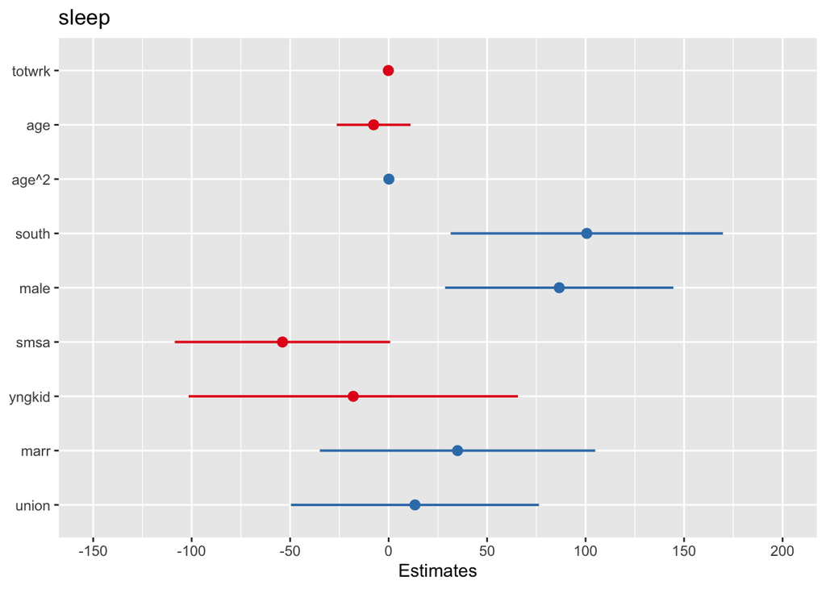

Шкалированные доверительные интервалы

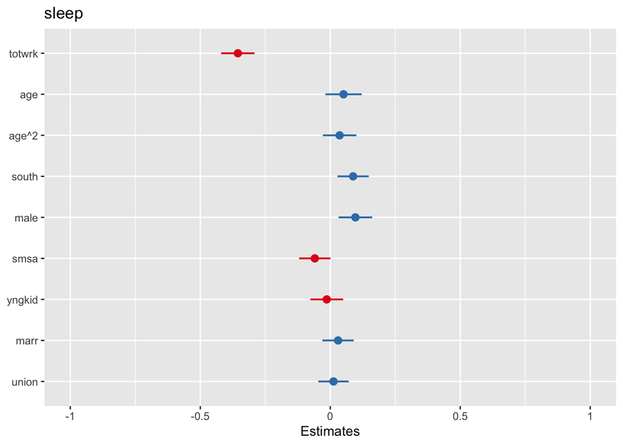

## 2.2 cost equation

Для набора данных `Electricity` рассмотрим линейную регрессию **log(cost) на log(q), log^2(q), log(pl), log^2(pl), log(pk), log^2(pk), log(pf), log^2(pf)**

Ниже приведены 99%-доверительные интервалы для коэффициентов.

```
                0.5 % 99.5 %
(Intercept)  -105.542 16.735
log(q)          0.312  0.480
I(log(q)^2)     0.025  0.037
log(pl)        -5.573 22.240
I(log(pl)^2)   -1.230  0.319
log(pk)        -3.536  4.408
I(log(pk)^2)   -0.525  0.453
log(pf)        -0.709  2.507
I(log(pf)^2)   -0.272  0.211
```

Какие коэффициенты значимы при уровне значимости 1%? Ответ

```
======================
Коэффициент Значимость
----------------------
(Intercept)  Незначим
log(q)        Значим
I(log(q)2)    Значим
log(pl)      Незначим
I(log(pl)2)  Незначим
log(pk)      Незначим
I(log(pk)2)  Незначим
log(pf)      Незначим
I(log(pf)2)  Незначим
----------------------
```

Визуализация доверительных интервалов как есть (в одном масштабе)

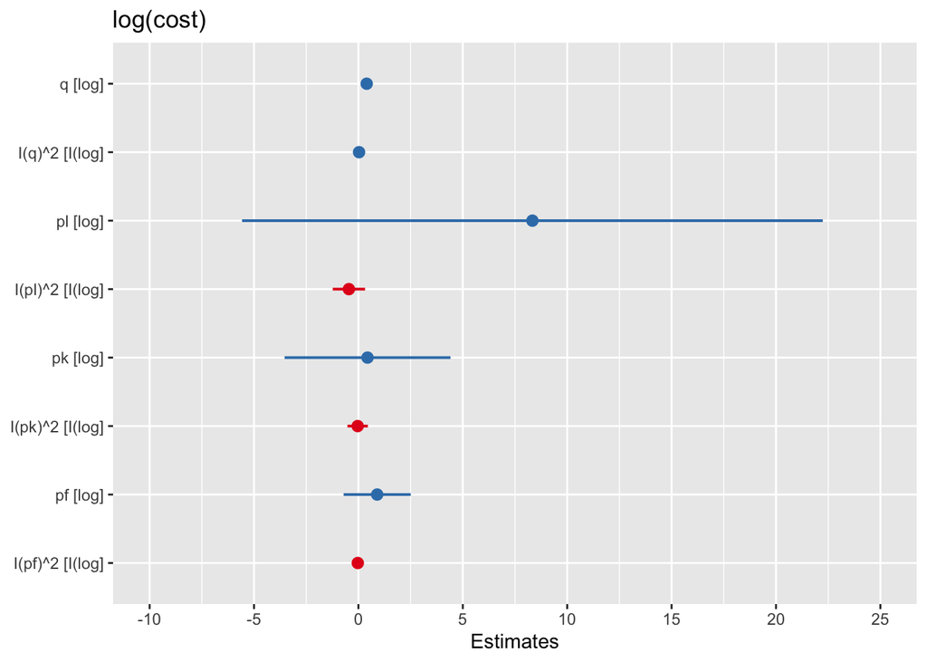

Шкалированные доверительные интервалы

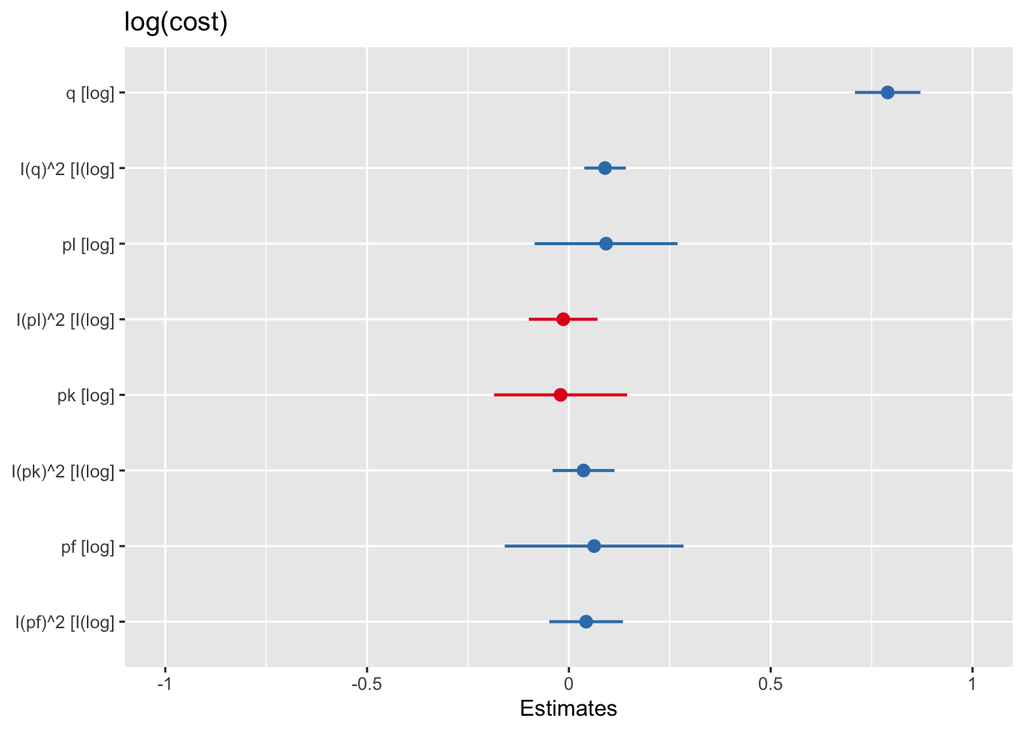

# 3 Доверителные интервалы и сравнение моделей

Результаты подгонки:

```
=======================================================
                            Dependent variable:
                    -----------------------------------
                                   sleep
                       Север        Юг         общая
                        (1)         (2)         (3)
-------------------------------------------------------
totwrk               -0.159***    -0.074     -0.147***
                      (0.018)     (0.045)     (0.017)

age                   -5.507      -12.882     -8.675
                     (12.557)    (25.039)    (11.271)

I(age2)                0.084       0.273       0.140
                      (0.150)     (0.299)     (0.135)

smsa                 -59.812*     16.055     -69.924**
                     (35.379)    (96.789)    (32.330)

marr                  28.034     152.296*     47.598
                     (46.960)    (86.153)    (41.450)

Constant            3664.188*** 3435.410*** 3675.413***
                     (244.380)   (494.979)   (219.803)

-------------------------------------------------------
Observations            576         130         706
R2                     0.129       0.140       0.118
Adjusted R2            0.122       0.106       0.112
Residual Std. Error   421.078     393.300     418.809
F Statistic          16.928***   4.043***    18.768***
=======================================================
Note:                       *p<0.1; **p<0.05; ***p<0.01
```

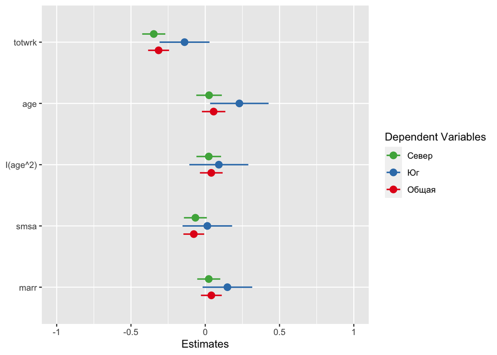